# Data Science Projekt - Gruppe 9

Authors

Erfan Abollahzadegohari

Romisa Moslemi

Shaghayegh Rokhsarighadikolaei

Kimiya Sohrabzadeh

Farbod Moayed

# Einleitung

Die akute lymphoblastische Leukämie (ALL) ist eine hämatologische Erkrankung, bei der sich lymphatische Vorläuferzellen unkontrolliert vermehren. Genexpressionsdaten ermöglichen es, molekulare Unterschiede zwischen Leukämieproben systematisch zu untersuchen und potenziell biologisch relevante Gruppen anhand ihrer Expressionsprofile zu identifizieren.

Ziel dieser Projektarbeit ist die Anwendung von Methoden der Datenvorverarbeitung, Qualitätskontrolle, Dimensionsreduktion, Clusteranalyse und des maschinellen Lernens auf reale Microarray-Genexpressionsdaten.

Für die Qualitätskontrolle und die explorative Analyse wurde zunächst der Bioconductor-Datensatz `ALLMLL` verwendet. Dieser enthält Affymetrix-Microarray-Rohdaten und ermöglicht dadurch die Untersuchung der Rohintensitäten sowie eine RMA-Normalisierung.

Da der verwendete `ALLMLL`-Datensatz keine geeignete biologische Zielvariable für eine überwachte Klassifikation enthält, wurde für den Machine-Learning-Teil zusätzlich der verwandte Bioconductor-Datensatz `ALL` verwendet. Dieser enthält bereits verarbeitete Genexpressionsdaten sowie phänotypische Informationen, die eine Unterscheidung zwischen B-Zell-ALL und T-Zell-ALL ermöglichen.

# Fragestellungen

Die Analyse untersucht folgende Fragestellungen:

1. Weisen die Microarray-Rohdaten technische Unterschiede oder auffällige Proben auf und können diese durch eine geeignete Normalisierung reduziert werden?
2. Lassen sich anhand der Genexpressionsprofile natürliche Gruppierungen der Proben mittels PCA und hierarchischem Clustering erkennen?
3. Können Genexpressionsprofile verwendet werden, um B-Zell-ALL und T-Zell-ALL mittels eines Machine-Learning-Modells zu unterscheiden?
4. Welche Gene tragen besonders zur Unterscheidung zwischen B-Zell-ALL und T-Zell-ALL bei?

# Hypothesen

Für die explorative Analyse wird angenommen, dass Unterschiede in den Genexpressionsprofilen zu einer strukturierten Anordnung der Proben in PCA und Clustering führen.

Für die überwachte Klassifikation wird folgende Hypothese formuliert:

**H1:** B-Zell-ALL und T-Zell-ALL weisen unterschiedliche Genexpressionsprofile auf, sodass eine Klassifikation der beiden Gruppen anhand ihrer Genexpression mit einer Leistung oberhalb des Zufallsniveaus möglich ist.

Die Nullhypothese lautet entsprechend:

**H0:** Die Genexpressionsprofile enthalten keine ausreichende Information zur zuverlässigen Unterscheidung zwischen B-Zell-ALL und T-Zell-ALL.

# Datensätze und Datenaufbereitung

## ALLMLL-Datensatz

Für die Qualitätskontrolle und die explorative Datenanalyse wurde der Bioconductor-Datensatz `ALLMLL` verwendet. Für die Analyse wurde das Objekt `MLL.A` geladen, das Affymetrix-Microarray-Rohdaten enthält.

Der verwendete Datensatz umfasst 20 Microarrays. Die Rohdaten wurden zunächst hinsichtlich ihrer Intensitätsverteilungen und möglicher technischer Auffälligkeiten untersucht.

Anschließend wurden die Expressionsdaten mit der Robust Multi-array Average (RMA)-Methode normalisiert. Die RMA-Normalisierung umfasst Hintergrundkorrektur, Quantilnormalisierung und die Zusammenfassung der Probe-Set-Intensitäten zu Expressionswerten.

Die normalisierten Expressionsdaten wurden anschließend für die explorative Analyse, insbesondere PCA und Clustering, verwendet.

```r
# ============================================================
# Data Science Projekt - Gruppe 9
# Laden des Datensatzes und erste Datenexploration.
#
# Autor: Erfan Abdollahzadehgohari
# Datum: 09.08.2026
#
# Ziel:
# Installation der benötigten Pakete,
# Laden des Datensatzes und erste Datenexploration.
# ============================================================
# ------------------------------------------------------------
# Pakete installieren
# ------------------------------------------------------------

if (!require("BiocManager", quietly = TRUE))
  install.packages("BiocManager")
# ------------------------------------------------------------
# Benötigte Bioconductor-Pakete installieren
# ------------------------------------------------------------

if (!require("ALLMLL", quietly = TRUE))
  BiocManager::install("ALLMLL")
# ------------------------------------------------------------
# Pakete laden
# ------------------------------------------------------------

library(ALLMLL)

# ------------------------------------------------------------
# Verfügbare Datensätze anzeigen
# ------------------------------------------------------------

data(package = "ALLMLL")

# ------------------------------------------------------------
# Datensatz laden
# ------------------------------------------------------------

data("MLL.A")
# Klasse des Datensatzes anzeigen
class(MLL.A)
```

```
[1] "AffyBatch"
attr(,"package")
[1] "affy"
```

```r
# ------------------------------------------------------------
# Informationen über die Proben
# ------------------------------------------------------------

sampleNames(MLL.A)
```

```
 [1] "JD-ALD009-v5-U133A.CEL"    "JD-ALD051-v5-U133A.CEL"
 [3] "JD-ALD052-v5-U133A.CEL"    "JD-ALD057-v5-U133A.CEL"
 [5] "JD-ALD078-v5-U133A.CEL"    "JD-ALD180-v5-U133A.CEL"
 [7] "JD-ALD226-NA-v5-U133A.CEL" "JD-ALD232-v5-U133A.CEL"
 [9] "JD-ALD237-v5-U133A.CEL"    "JD-ALD244-v5-U133A.CEL"
[11] "JD-ALD294-v5-U133A.CEL"    "JD-ALD380-v5-U133A.CEL"
[13] "JD-ALD381-v5-U133A.CEL"    "JD-ALD384-v5-U133A.CEL"
[15] "JD-ALD385-v5-U133A.CEL"    "JD-ALD420-v5-U133A.CEL"
[17] "JD-ALD421-v5-U133A.CEL"    "JD-ALD431-v5-U133A.CEL"
[19] "JD-ALD433-v5-U133A.CEL"    "JD-ALD520-v5-U133A.CEL"
```

```r
# Informationen zu den Patienten (Metadaten)

pData(MLL.A)
```

```
                          sample
JD-ALD009-v5-U133A.CEL         1
JD-ALD051-v5-U133A.CEL         2
JD-ALD052-v5-U133A.CEL         3
JD-ALD057-v5-U133A.CEL         4
JD-ALD078-v5-U133A.CEL         5
JD-ALD180-v5-U133A.CEL         6
JD-ALD226-NA-v5-U133A.CEL      7
JD-ALD232-v5-U133A.CEL         8
JD-ALD237-v5-U133A.CEL         9
JD-ALD244-v5-U133A.CEL        10
JD-ALD294-v5-U133A.CEL        11
JD-ALD380-v5-U133A.CEL        12
JD-ALD381-v5-U133A.CEL        13
JD-ALD384-v5-U133A.CEL        14
JD-ALD385-v5-U133A.CEL        15
JD-ALD420-v5-U133A.CEL        16
JD-ALD421-v5-U133A.CEL        17
JD-ALD431-v5-U133A.CEL        18
JD-ALD433-v5-U133A.CEL        19
JD-ALD520-v5-U133A.CEL        20
```

```r
# ------------------------------------------------------------
# Struktur des Datensatzes untersuchen
# ------------------------------------------------------------

MLL.A
```

```
AffyBatch object
size of arrays=712x712 features (23 kb)
cdf=HG-U133A (22283 affyids)
number of samples=20
number of genes=22283
annotation=hgu133a
notes=
```

```r
# ------------------------------------------------------------
# Informationen über das AffyBatch-Objekt
# ------------------------------------------------------------

annotation(MLL.A)
```

```
[1] "hgu133a"
```

```r
sampleNames(MLL.A)
```

```
 [1] "JD-ALD009-v5-U133A.CEL"    "JD-ALD051-v5-U133A.CEL"
 [3] "JD-ALD052-v5-U133A.CEL"    "JD-ALD057-v5-U133A.CEL"
 [5] "JD-ALD078-v5-U133A.CEL"    "JD-ALD180-v5-U133A.CEL"
 [7] "JD-ALD226-NA-v5-U133A.CEL" "JD-ALD232-v5-U133A.CEL"
 [9] "JD-ALD237-v5-U133A.CEL"    "JD-ALD244-v5-U133A.CEL"
[11] "JD-ALD294-v5-U133A.CEL"    "JD-ALD380-v5-U133A.CEL"
[13] "JD-ALD381-v5-U133A.CEL"    "JD-ALD384-v5-U133A.CEL"
[15] "JD-ALD385-v5-U133A.CEL"    "JD-ALD420-v5-U133A.CEL"
[17] "JD-ALD421-v5-U133A.CEL"    "JD-ALD431-v5-U133A.CEL"
[19] "JD-ALD433-v5-U133A.CEL"    "JD-ALD520-v5-U133A.CEL"
```

```r
protocolData(MLL.A)
```

```
An object of class 'AnnotatedDataFrame': none
```

```r
experimentData(MLL.A)
```

```
Experiment data
  Experimenter name:
  Laboratory:
  Contact information:
  Title:
  URL:
  PMIDs:
  No abstract available.
  Information is available on: preprocessing
  notes:
   :
```

```r
# Anzahl der Proben
length(sampleNames(MLL.A))
```

```
[1] 20
```

```r
# Verwendete Plattform
annotation(MLL.A)
```

```
[1] "hgu133a"
```

```r
# ------------------------------------------------------------
# Ende des Data-Wrangling-Schritts
# Die Daten wurden erfolgreich geladen und ihre Struktur geprüft.
# Die weitere Verarbeitung erfolgt in 02_QA_QC.R.
# ------------------------------------------------------------
```

## ALL-Datensatz für die Klassifikation

Für die überwachte Machine-Learning-Analyse wurde der Bioconductor-Datensatz `ALL` verwendet. Dieser enthält bereits vorverarbeitete Genexpressionsdaten sowie phänotypische Informationen zu den untersuchten Leukämieproben.

Für die Klassifikation wurden ausschließlich Proben mit B-Zell-ALL oder T-Zell-ALL berücksichtigt. Insgesamt standen 128 Proben zur Verfügung, davon 95 B-Zell-ALL-Proben und 33 T-Zell-ALL-Proben.

Die Expressionsmatrix enthielt 12.625 Probe Sets. Für die weitere Analyse wurde die Matrix so angeordnet, dass die Zeilen den Proben und die Spalten den Genexpressionsmerkmalen entsprechen.

## Vorbereitung für das Machine Learning

Die 128 Proben wurden stratifiziert in Trainings- und Testdaten aufgeteilt. Dabei wurden 80 % der Proben für das Training und 20 % für die unabhängige Testung verwendet.

Der Trainingsdatensatz umfasste 102 Proben (76 B-Zell-ALL und 26 T-Zell-ALL), während der Testdatensatz 26 Proben (19 B-Zell-ALL und 7 T-Zell-ALL) enthielt.

Um die hohe Anzahl an Genexpressionsmerkmalen zu reduzieren, wurde eine varianzbasierte Feature-Selektion durchgeführt. Dabei wurden die 100 Probe Sets mit der höchsten Varianz ausgewählt.

Um Information Leakage zu vermeiden, erfolgte diese Feature-Selektion ausschließlich anhand der Trainingsdaten. Die ausgewählten Merkmale wurden anschließend auf die entsprechenden Testdaten übertragen.

# Qualitätskontrolle und Normalisierung

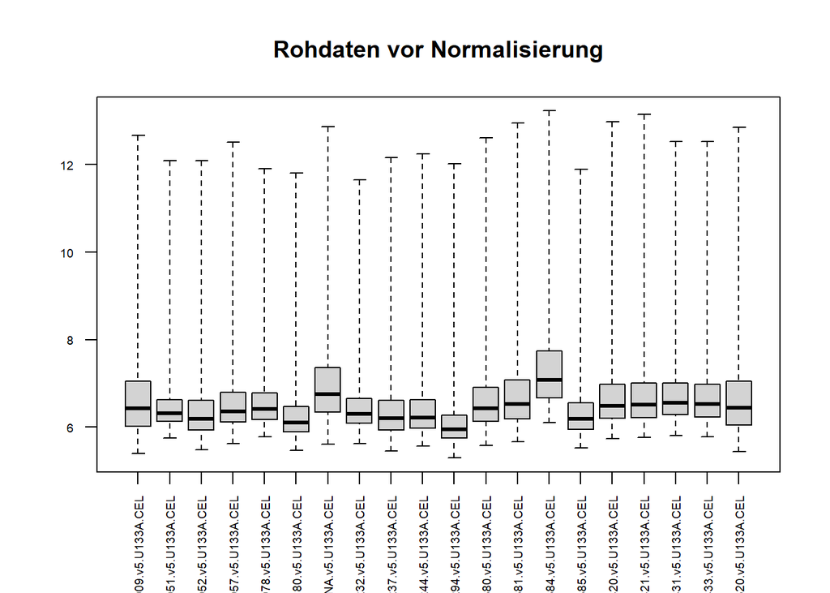

```r
# ------------------------------------------------------------
# 1. Pakete laden
# ------------------------------------------------------------

library(ALLMLL)
library(affy)


# ------------------------------------------------------------
# 2. Rohdaten laden
# ------------------------------------------------------------

data("MLL.A")


# ------------------------------------------------------------
# 3. Quality Assessment der Rohdaten
# ------------------------------------------------------------

# Boxplot der Rohintensitäten
boxplot(
  MLL.A,
  main = "Rohdaten vor Normalisierung",
  las = 2,
  cex.axis = 0.6
)
```

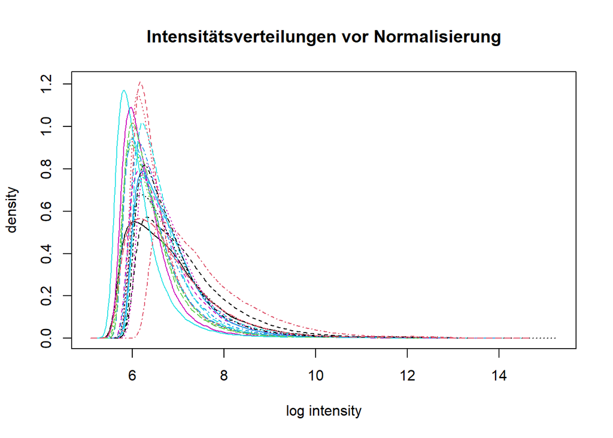

```r
# Dichteverteilungen der Rohintensitäten
hist(
  MLL.A,
  main = "Intensitätsverteilungen vor Normalisierung"
)
```

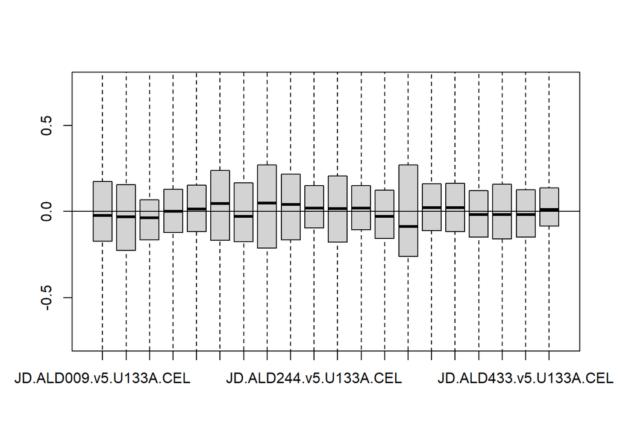

```r
if (!require("affyPLM", quietly = TRUE))
  BiocManager::install("affyPLM")

library(affyPLM)

fit <- fitPLM(MLL.A)

RLE(fit)
```

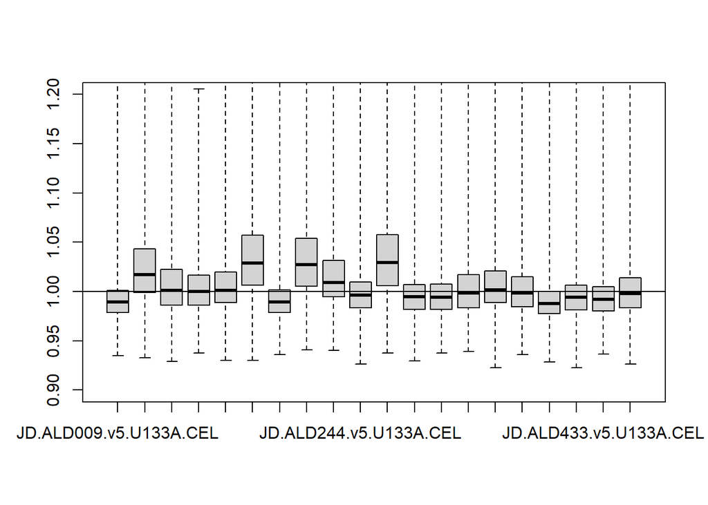

```r
NUSE(fit)
```

```r
# ------------------------------------------------------------
# 4. RMA-Normalisierung
# ------------------------------------------------------------

MLL.A_rma <- rma(MLL.A)
```

```
Background correcting
Normalizing
Calculating Expression
```

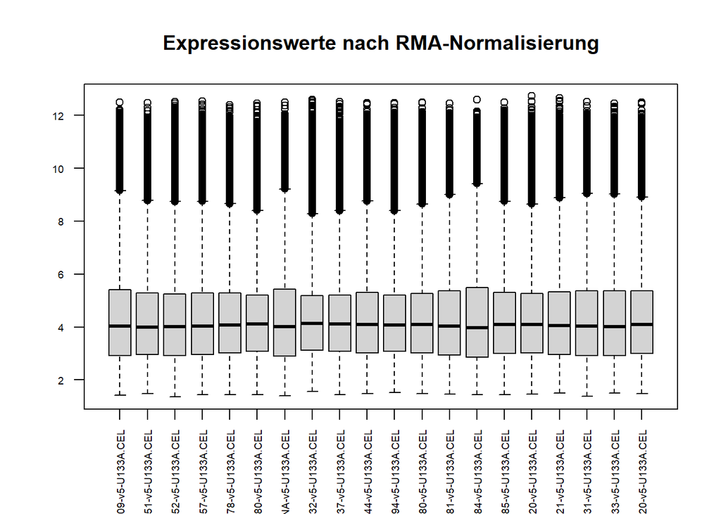

```r
# ------------------------------------------------------------
# 5. Kontrolle nach RMA-Normalisierung
# ------------------------------------------------------------

boxplot(
  exprs(MLL.A_rma),
  main = "Expressionswerte nach RMA-Normalisierung",
  las = 2,
  cex.axis = 0.6
)
```

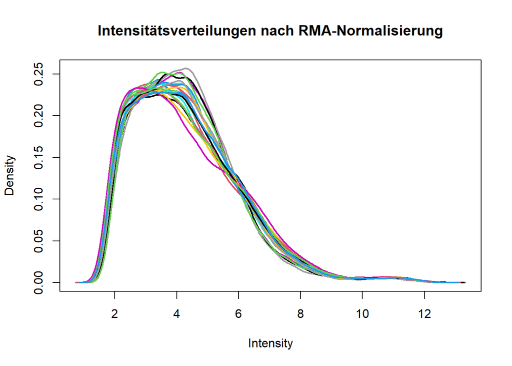

```r
# Nach dem RMA-Normalisierung weisen alle Proben nahezu identische Medianwerte und sehr aehnliche Verteilungen auf.
# Dies zeigt, dass techniche Unterschiede zwischen microarrays erfolfreich redutziert wurden und die expersionswert nin vergleichbar sind.
if (!require("limma", quietly = TRUE))
  BiocManager::install("limma")
library(limma)
plotDensities(
  exprs(MLL.A_rma),
  main = "Intensitätsverteilungen nach RMA-Normalisierung",
  legend = FALSE
)
```

```r
#Qualitätskontrolle nach der RMA-Normalisierung:
#Nach der RMA-Normalisierung zeigen alle 20 Microarray-Proben nahezu identische Intensitätsverteilungen.
#Die Dichtekurven überlagern sich fast vollständig, was auf eine erfolgreiche Beseitigung systematischer technischer Unterschiede zwischen den Arrays hinweist.
#Die Daten weisen somit eine hohe Vergleichbarkeit auf und sind für die anschließenden statistischen Analysen geeignet.

# ------------------------------------------------------------
# 6. Normalisierte Daten speichern
# ------------------------------------------------------------

saveRDS(
  MLL.A_rma,
  file = "../data/processed/MLL_A_rma.rds"
)

# ============================================================
# Zusammenfassung der Qualitätskontrolle
# ============================================================

# Die Rohdaten wurden erfolgreich auf ihre Qualität überprüft.
# Es wurden folgende Analysen durchgeführt:
# - Boxplot der Rohintensitäten
# - Dichteverteilungen der Rohdaten
# - RLE-Plot
# - NUSE-Plot
# - RMA-Normalisierung
# - Boxplot nach RMA-Normalisierung
# - Dichteplot nach RMA-Normalisierung
#
# Ergebnis:
# Die Proben zeigen nach der RMA-Normalisierung nahezu identische
# Intensitätsverteilungen. Es wurden keine auffälligen Ausreißer
# oder Qualitätsprobleme festgestellt.
#
# Die Daten sind damit für die explorative Datenanalyse
# (PCA, Clustering und Heatmaps) geeignet.
# ============================================================
```

## Qualitätskontrolle der Rohdaten

Vor der weiteren Analyse wurden die Microarray-Rohdaten des `ALLMLL`-Datensatzes auf technische Unterschiede und mögliche auffällige Arrays untersucht.

Zunächst wurden Boxplots und Intensitätsverteilungen der Rohdaten erstellt. Dabei waren Unterschiede zwischen den einzelnen Arrays erkennbar, die eine Normalisierung der Daten erforderlich machten.

Zusätzlich wurde mit dem Bioconductor-Paket `affyPLM` ein Probe-Level-Modell angepasst. Zur Beurteilung der Arrayqualität wurden die Relative Log Expression (RLE) und der Normalized Unscaled Standard Error (NUSE) untersucht.

Die RLE- und NUSE-Darstellungen zeigten keine deutlich auffälligen Arrays, sodass keine Probe aufgrund der Qualitätskontrolle aus der weiteren Analyse ausgeschlossen wurde.

## RMA-Normalisierung

Zur Normalisierung der Microarray-Daten wurde die Robust Multi-array Average (RMA)-Methode verwendet.

Die RMA-Verarbeitung umfasst Hintergrundkorrektur, Quantilnormalisierung und die Zusammenfassung der Probe-Set-Signale zu Expressionswerten.

Nach der Normalisierung wurden die Expressionsverteilungen erneut mithilfe von Boxplots und Dichteverteilungen kontrolliert. Im Vergleich zu den Rohdaten zeigten die normalisierten Arrays vergleichbarere Expressionsverteilungen.

Die normalisierten Expressionswerte wurden anschließend als Grundlage für die explorative Analyse und das Clustering verwendet.

## Zwischenfazit

Die Qualitätskontrolle ergab keine Hinweise auf stark auffällige Arrays, die aus dem Datensatz entfernt werden mussten. Durch die RMA-Normalisierung wurden technische Unterschiede zwischen den Expressionsverteilungen reduziert und eine vergleichbare Grundlage für die nachfolgenden Analysen geschaffen.

# Explorative Datenanalyse und Clustering

```r
# ------------------------------------------------------------
# 1. Normalisierte Daten laden
# ------------------------------------------------------------

library(Biobase)

MLL.A_rma <- readRDS("../data/processed/MLL_A_rma.rds")
# Expressionsmatrix extrahieren
expr_matrix <- exprs(MLL.A_rma)

dim(expr_matrix)
```

```
[1] 22283    20
```

```r
# Für PCA Sample
expr_matrix_t <- t(expr_matrix)

dim(expr_matrix_t)
```

```
[1]    20 22283
```

```r
# ------------------------------------------------------------
# 3. PCA durchführen
# ------------------------------------------------------------

pca_result <- prcomp(
  expr_matrix_t,
  center = TRUE,
  scale. = FALSE
)
summary(pca_result)
```

```
Importance of components:
                           PC1     PC2     PC3      PC4      PC5      PC6
Standard deviation     25.5709 21.1434 17.6019 15.79153 14.35801 12.14580
Proportion of Variance  0.2167  0.1481  0.1027  0.08263  0.06831  0.04888
Cumulative Proportion   0.2167  0.3648  0.4675  0.55011  0.61842  0.66730
                            PC7      PC8     PC9    PC10    PC11    PC12
Standard deviation     11.16241 10.40467 9.83660 9.23142 9.07416 8.88682
Proportion of Variance  0.04129  0.03587 0.03206 0.02824 0.02728 0.02617
Cumulative Proportion   0.70859  0.74446 0.77653 0.80476 0.83205 0.85822
                          PC13    PC14    PC15   PC16   PC17    PC18    PC19
Standard deviation     8.73010 8.23045 8.00802 7.8471 7.6327 7.24069 6.89348
Proportion of Variance 0.02526 0.02245 0.02125 0.0204 0.0193 0.01737 0.01575
Cumulative Proportion  0.88347 0.90592 0.92717 0.9476 0.9669 0.98425 1.00000
                            PC20
Standard deviation     6.472e-14
Proportion of Variance 0.000e+00
Cumulative Proportion  1.000e+00
```

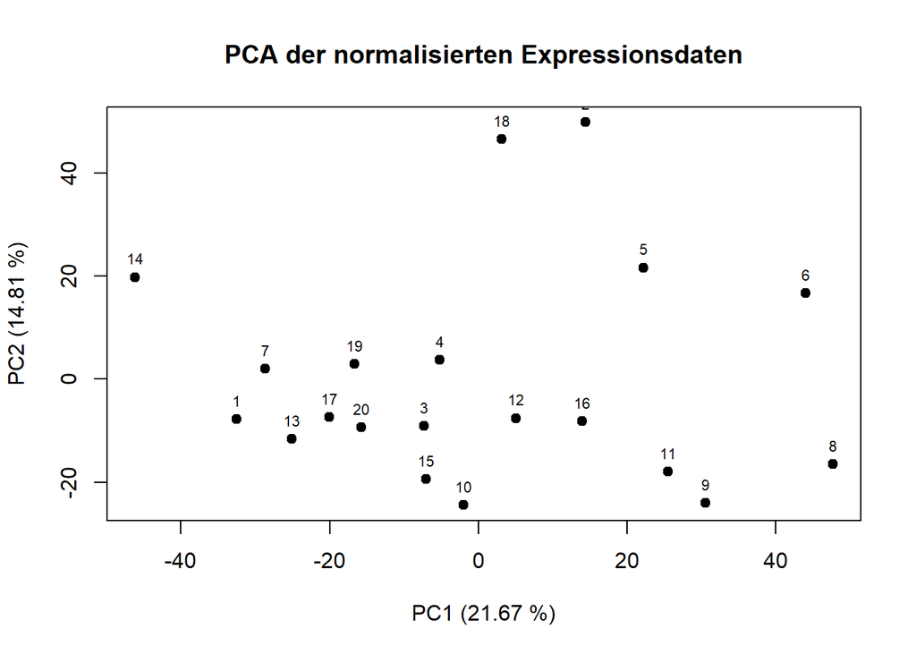

```r
# ------------------------------------------------------------
# 4. PCA-Plot
# ------------------------------------------------------------

plot(
  pca_result$x[, 1],
  pca_result$x[, 2],
  xlab = "PC1 (21.67 %)",
  ylab = "PC2 (14.81 %)",
  main = "PCA der normalisierten Expressionsdaten",
  pch = 19
)
text(
  pca_result$x[, 1],
  pca_result$x[, 2],
  labels = 1:20,
  pos = 3,
  cex = 0.7
)
```

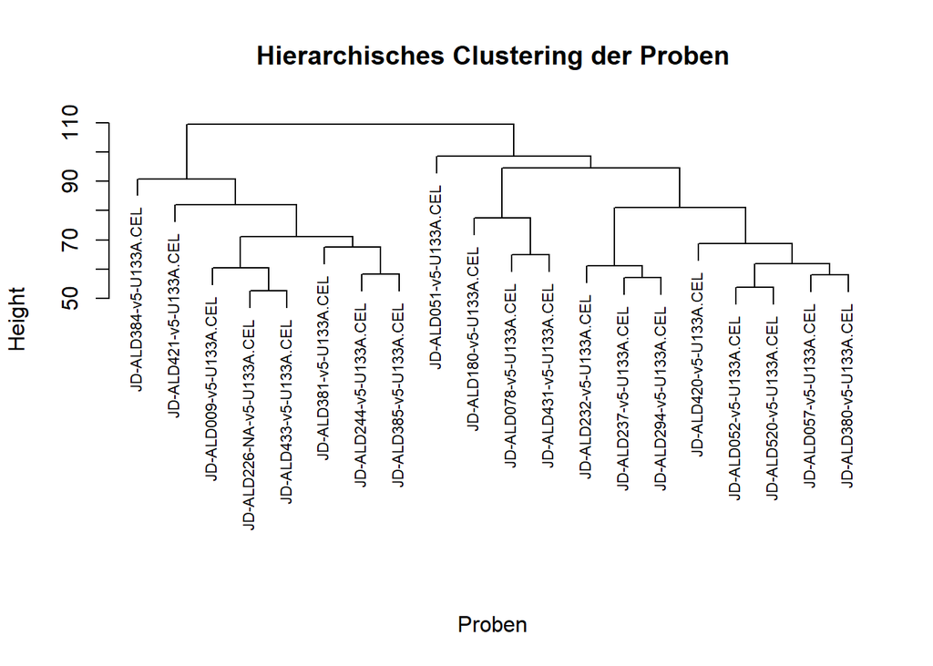

```r
# Die PCA zeigt Unterschiede in den globalen Expressionsprofilen
# der 20 Proben.
# PC1 erklärt 21.67 % und PC2 14.81 % der Gesamtvarianz.
# Zusammen erklären die ersten beiden Hauptkomponenten 36.48 %.
#
# Im PCA-Plot ist eine Strukturierung der Proben erkennbar.
# Einige Proben liegen deutlich vom zentralen Bereich entfernt.
# Eine biologische Interpretation dieser Gruppen ist anhand der
# PCA allein jedoch nicht möglich.

# ------------------------------------------------------------
# 5. Hierarchisches Clustering
# ------------------------------------------------------------

# Euklidische Distanz zwischen den Proben
sample_dist <- dist(expr_matrix_t)

# Hierarchisches Clustering
hc <- hclust(sample_dist, method = "complete")

# Dendrogramm
plot(
  hc,
  main = "Hierarchisches Clustering der Proben",
  xlab = "Proben",
  sub = "",
  cex = 0.7
)
```

```r
# Das hierarchische Clustering zeigt eine erkennbare Struktur
# innerhalb der 20 Proben.
# Proben mit ähnlichen globalen Expressionsprofilen werden
# bei geringeren Distanzen zusammengeführt.
#
# Es sind größere sowie mehrere kleinere Gruppen erkennbar.
# Dies stimmt grundsätzlich mit der in der PCA beobachteten
# Heterogenität der Expressionsprofile überein.
#
# Eine biologische Zuordnung der Cluster ist anhand der
# Expressionsdaten allein jedoch nicht möglich.
# ------------------------------------------------------------
# 6. Heatmap der variabelsten Probe-Sets
# ------------------------------------------------------------

# Varianz jedes Probe-Sets berechnen
gene_var <- apply(expr_matrix, 1, var)

# 50 Probe-Sets mit der höchsten Varianz auswählen
top50 <- order(gene_var, decreasing = TRUE)[1:50]

# Expressionswerte dieser Probe-Sets
heatmap_data <- expr_matrix[top50, ]

dim(heatmap_data)
```

```
[1] 50 20
```

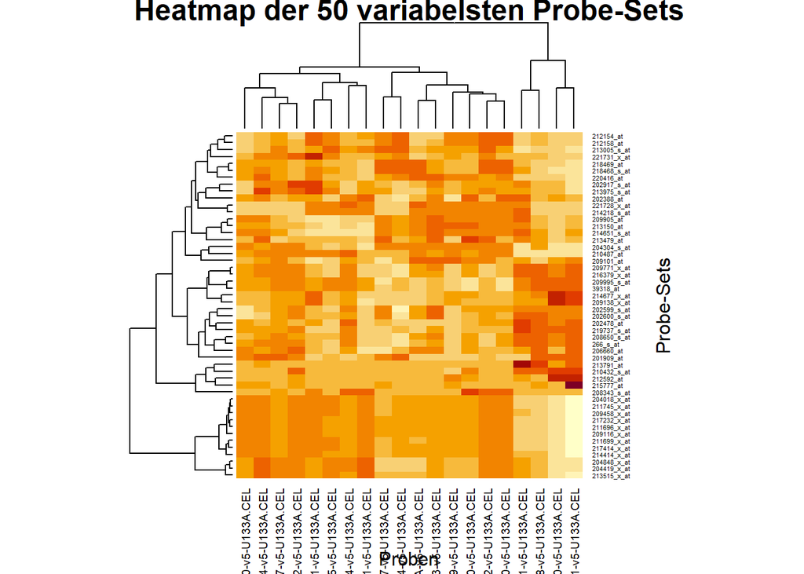

```r
# Heatmap erstellen
heatmap(
  heatmap_data,
  scale = "row",
  Colv = TRUE,
  main = "Heatmap der 50 variabelsten Probe-Sets",
  xlab = "Proben",
  ylab = "Probe-Sets",
  cexCol = 0.7,
  cexRow = 0.4
)
```

```r
# ------------------------------------------------------------
# 7. Biologische Gruppen der Proben untersuchen
# ------------------------------------------------------------

pheno <- pData(MLL.A_rma)

dim(pheno)
```

```
[1] 20  1
```

```r
colnames(pheno)
```

```
[1] "sample"
```

```r
pheno
```

```
                          sample
JD-ALD009-v5-U133A.CEL         1
JD-ALD051-v5-U133A.CEL         2
JD-ALD052-v5-U133A.CEL         3
JD-ALD057-v5-U133A.CEL         4
JD-ALD078-v5-U133A.CEL         5
JD-ALD180-v5-U133A.CEL         6
JD-ALD226-NA-v5-U133A.CEL      7
JD-ALD232-v5-U133A.CEL         8
JD-ALD237-v5-U133A.CEL         9
JD-ALD244-v5-U133A.CEL        10
JD-ALD294-v5-U133A.CEL        11
JD-ALD380-v5-U133A.CEL        12
JD-ALD381-v5-U133A.CEL        13
JD-ALD384-v5-U133A.CEL        14
JD-ALD385-v5-U133A.CEL        15
JD-ALD420-v5-U133A.CEL        16
JD-ALD421-v5-U133A.CEL        17
JD-ALD431-v5-U133A.CEL        18
JD-ALD433-v5-U133A.CEL        19
JD-ALD520-v5-U133A.CEL        20
```

```r
# ============================================================
# Zusammenfassung der explorativen Analyse
# ============================================================

# PCA und hierarchisches Clustering zeigen eine heterogene Struktur
# der 20 Proben. Die Proben unterscheiden sich in ihren globalen
# Expressionsprofilen.

# Die Heatmap der 50 variabelsten Probe-Sets zeigt ebenfalls
# unterschiedliche Expressionsmuster zwischen den Proben.

# Eine biologische Zuordnung der beobachteten Cluster ist anhand
# der im ExpressionSet enthaltenen Metadaten derzeit nicht möglich.
# ============================================================
```

## Hauptkomponentenanalyse

Zur explorativen Untersuchung der normalisierten Genexpressionsdaten wurde eine Hauptkomponentenanalyse (Principal Component Analysis, PCA) durchgeführt.

Die PCA reduziert die hohe Dimensionalität der Genexpressionsdaten auf wenige Hauptkomponenten. Dadurch können Ähnlichkeiten und Unterschiede zwischen den Proben visuell untersucht werden, ohne vorher eine Klassenzugehörigkeit für die Proben vorzugeben.

Die PCA zeigte eine Strukturierung der untersuchten Proben anhand ihrer Genexpressionsprofile. Dies deutet darauf hin, dass zwischen den Proben systematische Unterschiede in der Genexpression vorhanden sind.

## Hierarchisches Clustering

Zusätzlich wurde ein hierarchisches Clustering der normalisierten Expressionsdaten durchgeführt. Dabei werden Proben entsprechend der Ähnlichkeit ihrer Genexpressionsprofile schrittweise zu Gruppen zusammengefasst.

Das Clustering ermöglicht eine unüberwachte Untersuchung der Datenstruktur, da die Gruppierung ausschließlich auf den Expressionsdaten basiert und keine vorher definierten Klassen verwendet werden.

Das hierarchische Clustering zeigte Gruppen von Proben mit ähnlichen Expressionsmustern. Eine biologische Zuordnung dieser Gruppen ist anhand der im ALLMLL-Datensatz verfügbaren Metadaten jedoch nicht möglich.

## Zwischenfazit

Die PCA und das hierarchische Clustering zeigen, dass die Genexpressionsdaten eine erkennbare interne Struktur besitzen. Damit liefern die explorativen Analysen Hinweise darauf, dass Expressionsunterschiede zwischen den untersuchten Proben vorhanden sind.

Da diese Analysen unüberwacht durchgeführt wurden, erlauben sie jedoch noch keine Aussage darüber, wie zuverlässig bestimmte biologische Klassen vorhergesagt werden können. Diese Fragestellung wird im folgenden Machine-Learning-Teil anhand der B- und T-Zell-ALL-Proben untersucht.

# Machine Learning

```r
# ============================================================
# Data Science Projekt - Gruppe 9
# Datei: 04_machine_learning.R
#
# Ziel:
# Untersuchung, ob Genexpressionsdaten zur Vorhersage einer
# Fragestellung:
# Können Genexpressionsprofile zur Unterscheidung von
# B-Zell-ALL und T-Zell-ALL verwendet werden?

# Hypothese:
# B-Zell-ALL und T-Zell-ALL weisen unterschiedliche
# Genexpressionsprofile auf, die eine Klassifikation ermöglichen.
# ============================================================
if (!require("BiocManager", quietly = TRUE))
  install.packages("BiocManager")

if (!requireNamespace("ALL", quietly = TRUE)) {
  BiocManager::install("ALL")
}

library(ALL)
data(ALL)

ALL
```

```
ExpressionSet (storageMode: lockedEnvironment)
assayData: 12625 features, 128 samples
  element names: exprs
protocolData: none
phenoData
  sampleNames: 01005 01010 ... LAL4 (128 total)
  varLabels: cod diagnosis ... date last seen (21 total)
  varMetadata: labelDescription
featureData: none
experimentData: use 'experimentData(object)'
  pubMedIds: 14684422 16243790
Annotation: hgu95av2
```

```r
dim(exprs(ALL))
```

```
[1] 12625   128
```

```r
colnames(pData(ALL))
```

```
 [1] "cod"            "diagnosis"      "sex"            "age"
 [5] "BT"             "remission"      "CR"             "date.cr"
 [9] "t(4;11)"        "t(9;22)"        "cyto.normal"    "citog"
[13] "mol.biol"       "fusion protein" "mdr"            "kinet"
[17] "ccr"            "relapse"        "transplant"     "f.u"
[21] "date last seen"
```

```r
table(ALL$BT)
```

```
 B B1 B2 B3 B4  T T1 T2 T3 T4
 5 19 36 23 12  5  1 15 10  2
```

```r
table(ALL$mol.biol)
```

```
ALL1/AF4  BCR/ABL E2A/PBX1      NEG   NUP-98  p15/p16
      10       37        5       74        1        1
```

```r
# ------------------------------------------------------------
# 2. Zielvariable B-Zell-ALL vs. T-Zell-ALL erstellen
# ------------------------------------------------------------

# Vorhandene B/T-Klassen ansehen
table(ALL$BT)
```

```
 B B1 B2 B3 B4  T T1 T2 T3 T4
 5 19 36 23 12  5  1 15 10  2
```

```r
# Alle B-Untergruppen zu "B" und alle T-Untergruppen zu "T"
target <- ifelse(
  grepl("^B", ALL$BT),
  "B",
  "T"
)

target <- factor(target)

# Verteilung der Zielvariable kontrollieren
table(target)
```

```
target
 B  T
95 33
```

```r
# ------------------------------------------------------------

# 3.Erstellung von Eingabematrix für Machine Learning
# ------------------------------------------------------------

# Expressionsmatrix extrahieren und transponieren
#
X <- t(exprs(ALL))

# Für Machine Learning (kontroll):

dim(X)
```

```
[1]   128 12625
```

```r
nrow(X)
```

```
[1] 128
```

```r
length(target)
```

```
[1] 128
```

```r
# ------------------------------------------------------------
# 4. Trainings- und Testdaten
# ------------------------------------------------------------

set.seed(123)

# Indizes für B- und T-Proben
idx_B <- which(target == "B")
idx_T <- which(target == "T")

# Auswahl 80 % jeder Klasse für Training
train_B <- sample(idx_B, size = round(0.8 * length(idx_B)))
train_T <- sample(idx_T, size = round(0.8 * length(idx_T)))

train_idx <- c(train_B, train_T)

# Trainingsdaten
X_train <- X[train_idx, ]
y_train <- target[train_idx]

# Testdaten
X_test <- X[-train_idx, ]
y_test <- target[-train_idx]
dim(X_train)
```

```
[1]   102 12625
```

```r
dim(X_test)
```

```
[1]    26 12625
```

```r
table(y_train)
```

```
y_train
 B  T
76 26
```

```r
table(y_test)
```

```
y_test
 B  T
19  7
```

```r
# ------------------------------------------------------------
# 5. Feature-Auswahl
# ------------------------------------------------------------

# Berechnung der Varianz jedes Probe-Sets anhand der Trainingsdaten
gene_var <- apply(X_train, 2, var)

# Auswahl der 100 Probe-Sets mit der höchsten Varianz
top_genes <- order(gene_var, decreasing = TRUE)[1:100]

# Reduzierung von Trainings- und Testdaten auf dieselben Probe-Sets
X_train_selected <- X_train[, top_genes]
X_test_selected  <- X_test[, top_genes]

# Dimensionen kontrolle
dim(X_train_selected)
```

```
[1] 102 100
```

```r
dim(X_test_selected)
```

```
[1]  26 100
```

```r
# ------------------------------------------------------------
# 6. LASSO-logistische Regression
# ------------------------------------------------------------

# Paket installieren

if (!requireNamespace("glmnet", quietly = TRUE)) {
  install.packages("glmnet", repos = "https://cloud.r-project.org")
}

library(glmnet)
# Zielvariable numerisch codieren:
# B = 0, T = 1

y_train_num <- ifelse(y_train == "T", 1, 0)

table(y_train_num)
```

```
y_train_num
 0  1
76 26
```

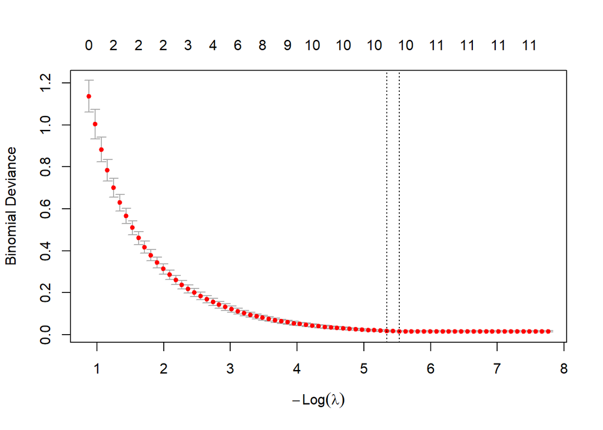

```r
# ------------------------------------------------------------
# 7. LASSO-Modell mit Cross-Validation
# ------------------------------------------------------------

set.seed(123)

cv_model <- cv.glmnet(
  x = X_train_selected,
  y = y_train_num,
  family = "binomial",
  alpha = 1,
  nfolds = 5
)

plot(cv_model)
```

```r
# Optimale Lambda-Werte

cv_model$lambda.min
```

```
[1] 0.003964906
```

```r
cv_model$lambda.1se
```

```
[1] 0.004775743
```

```r
coef_min <- coef(cv_model, s = "lambda.min")

# Anzahl der Koeffizienten ungleich 0
sum(coef_min != 0)
```

```
[1] 11
```

```r
coef_min
```

```
101 x 1 sparse Matrix of class "dgCMatrix"
             lambda.min
(Intercept) -6.22947281
38355_at     .
38514_at     .
41214_at     .
36638_at     .
39318_at     .
36108_at     .
38585_at     .
38096_f_at   .
38319_at     1.02637757
37006_at     .
32649_at     .
41470_at     .
39389_at    -0.09723941
31525_s_at   .
39839_at    -0.09906903
266_s_at     .
41723_s_at   .
38095_i_at   .
40775_at     .
33516_at     .
41266_at     .
33412_at     .
33705_at     .
38242_at    -0.04576942
40570_at    -0.07215432
41164_at    -0.20817927
36536_at     .
38604_at     .
36711_at     .
1110_at      0.36681841
35926_s_at   .
38994_at     .
39878_at     .
34168_at     .
37701_at     .
37809_at     .
37623_at     .
```

[output cut: 48 more lines]

```
37078_at     .
33274_f_at   .
34210_at     .
36927_at     .
40088_at     .
38052_at     .
33273_f_at   .
33232_at     .
995_g_at     .
36773_f_at   .
32794_g_at   .
40511_at     .
32855_at     .
33410_at     .
717_at       .
```

```r
# ------------------------------------------------------------
# 8. Vorhersage auf den Testdaten
# ------------------------------------------------------------

# Wahrscheinlichkeit für T-Zell-Klasse vorhersagen

prob_test <- predict(
  cv_model,
  newx = X_test_selected,
  s = "lambda.min",
  type = "response"
)

# Umwandlung In B bzw. T

pred_test <- ifelse(prob_test >= 0.5, "T", "B")

length(pred_test)
```

```
[1] 26
```

```r
# Vergleich des Vorhersage mit tatsächlicher Klasse

table(
  Tatsächlich = y_test,
  Vorhergesagt = pred_test
)
```

```
           Vorhergesagt
Tatsächlich  B  T
          B 19  0
          T  0  7
```

```r
# ------------------------------------------------------------
# 9. Modellgüte auf den Testdaten
# ------------------------------------------------------------

accuracy <- mean(pred_test == y_test)
accuracy
```

```
[1] 1
```

```r
# ------------------------------------------------------------
# 10. Sensitivität und Spezifität
# ------------------------------------------------------------

# Confusion Matrix

cm <- table(
  Tatsächlich = y_test,
  Vorhergesagt = pred_test
)

cm
```

```
           Vorhergesagt
Tatsächlich  B  T
          B 19  0
          T  0  7
```

```r
# Werte aus der Confusion Matrix

TP <- cm["T", "T"]
TN <- cm["B", "B"]
FP <- cm["B", "T"]
FN <- cm["T", "B"]

# Sensitivität: Anteil korrekt erkannter T-Proben
sensitivity <- TP / (TP + FN)

# Spezifität: Anteil korrekt erkannter B-Proben
specificity <- TN / (TN + FP)

sensitivity
```

```
[1] 1
```

```r
specificity
```

```
[1] 1
```

```r
# ------------------------------------------------------------
# 11. Robustheit der Klassifikation
# ------------------------------------------------------------

# Für reproduzierbare Ergebnisse
set.seed(123)

# Anzahl der Folds
k <- 5

# Speicher für Vorhersagen aller 128 Proben
cv_predictions <- rep(NA, length(target))

length(cv_predictions)
```

```
[1] 128
```

```r
# B- und T-Proben getrennt bestimmen
idx_B <- which(target == "B")
idx_T <- which(target == "T")

# Zufällig auf 5 Folds verteilen
fold_B <- sample(rep(1:k, length.out = length(idx_B)))
fold_T <- sample(rep(1:k, length.out = length(idx_T)))

# Fold-Zugehörigkeit speichern
fold_id <- rep(NA, length(target))

fold_id[idx_B] <- fold_B
fold_id[idx_T] <- fold_T

# Verteilung kontrollieren
table(Fold = fold_id, Klasse = target)
```

```
    Klasse
Fold  B  T
   1 19  7
   2 19  7
   3 19  7
   4 19  6
   5 19  6
```

```r
# ------------------------------------------------------------
# 11.3 Äußere 5-fache Cross-Validation
# ------------------------------------------------------------

cv_probabilities <- rep(NA, length(target))

# Alte Vorhersagen:
cv_predictions <- rep(NA, length(target))

for (i in 1:k) {

  # Trainings- und Testproben des aktuellen Folds
  train_i <- which(fold_id != i)
  test_i  <- which(fold_id == i)

  # Trainings- und Testdaten
  X_train_i <- X[train_i, ]
  X_test_i  <- X[test_i, ]

  y_train_i <- target[train_i]

  # Feature-Auswahl NUR anhand der Trainingsdaten
  gene_var_i <- apply(X_train_i, 2, var)
  top_genes_i <- order(gene_var_i, decreasing = TRUE)[1:100]

  X_train_i <- X_train_i[, top_genes_i]
  X_test_i  <- X_test_i[, top_genes_i]

  # B = 0, T = 1
  y_train_num_i <- ifelse(y_train_i == "T", 1, 0)

  # LASSO-Modell mit interner Cross-Validation
  model_i <- cv.glmnet(
    x = X_train_i,
    y = y_train_num_i,
    family = "binomial",
    alpha = 1,
    nfolds = 5
  )

  # Vorhersage für den jeweils ausgelassenen Fold
  prob_i <- predict(
    model_i,
    newx = X_test_i,
    s = "lambda.min",
    type = "response"
  )
cv_probabilities[test_i] <- as.numeric(prob_i)

  cv_predictions[test_i] <- ifelse(prob_i >= 0.5, "T", "B")
}
length(cv_probabilities)
```

```
[1] 128
```

```r
sum(is.na(cv_probabilities))
```

```
[1] 0
```

```r
# ------------------------------------------------------------
# 11.4 Ergebnisse der äußeren Cross-Validation
# ------------------------------------------------------------

# Kontrolle: liegt für alle Proben eine Vorhersage vor?
sum(is.na(cv_predictions))
```

```
[1] 0
```

```r
# Confusion Matrix
cv_cm <- table(
  Tatsächlich = target,
  Vorhergesagt = cv_predictions
)

cv_cm
```

```
           Vorhergesagt
Tatsächlich  B  T
          B 95  0
          T  0 33
```

```r
# Accuracy
cv_accuracy <- mean(cv_predictions == target)

cv_accuracy
```

```
[1] 1
```

```r
dim(X)
```

```
[1]   128 12625
```

```r
dim(X_train)
```

```
[1]   102 12625
```

```r
dim(X_test)
```

```
[1]    26 12625
```

```r
dim(X_train_selected)
```

```
[1] 102 100
```

```r
dim(X_test_selected)
```

```
[1]  26 100
```

```r
length(y_train)
```

```
[1] 102
```

```r
length(y_test)
```

```
[1] 26
```

```r
length(pred_test)
```

```
[1] 26
```

```r
dim(X_train)
```

```
[1]   102 12625
```

```r
dim(X_test)
```

```
[1]    26 12625
```

```r
dim(X_train_selected)
```

```
[1] 102 100
```

```r
dim(X_test_selected)
```

```
[1]  26 100
```

```r
# ------------------------------------------------------------
# Interpretation der äußeren Cross-Validation
# ------------------------------------------------------------

# Die äußere 5-fache Cross-Validation ergab eine Accuracy von 100 %.
# Alle 95 B-Zell- und alle 33 T-Zell-Proben wurden korrekt klassifiziert.
# Die Feature-Auswahl wurde in jedem Fold ausschließlich anhand der
# jeweiligen Trainingsdaten durchgeführt, wodurch Data Leakage vermieden wurde.
#
# Das Ergebnis deutet darauf hin, dass sich B- und T-Zell-ALL anhand
# der Genexpressionsprofile in diesem Datensatz sehr deutlich unterscheiden.
# Aufgrund der begrenzten Stichprobengröße sollte die Generalisierbarkeit
# auf unabhängige externe Datensätze dennoch vorsichtig interpretiert werden.


# ------------------------------------------------------------
# 12. ROC-Kurve und AUC
# ------------------------------------------------------------

# Paket install

if (!requireNamespace("pROC", quietly = TRUE)) {
  install.packages("pROC", repos = "https://cloud.r-project.org")
}

library(pROC)
# Numerische Zielvariable für die Testdaten:
# B = 0, T = 1
y_test_num <- ifelse(y_test == "T", 1, 0)

# ROC-Kurve aus den vorhergesagten Wahrscheinlichkeiten
roc_test <- roc(
  response = y_test_num,
  predictor = as.numeric(prob_test)
)
# AUC Berechnung
auc_test <- auc(roc_test)

auc_test
```

```
Area under the curve: 1
```

```r
# ------------------------------------------------------------
# 13. Vom LASSO ausgewählte Probe-Sets
# ------------------------------------------------------------

# Koeffizienten des finalen Modells bei lambda.min

coef_lasso <- coef(cv_model, s = "lambda.min")

# Koeffizienten als Matrix umwandeln
coef_matrix <- as.matrix(coef_lasso)

# Probe-Sets mit Koeffizient ungleich 0 bestimmen
selected_idx <- which(coef_matrix[, 1] != 0)

# Intercept entfernen
selected_idx <- selected_idx[
  rownames(coef_matrix)[selected_idx] != "(Intercept)"
]

# Ausgewählte Probe-Sets und ihre Koeffizienten anzeigen
selected_genes <- data.frame(
  ProbeSet = rownames(coef_matrix)[selected_idx],
  Koeffizient = coef_matrix[selected_idx, 1]
)

selected_genes
```

```
         ProbeSet Koeffizient
38319_at 38319_at  1.02637757
39389_at 39389_at -0.09723941
39839_at 39839_at -0.09906903
38242_at 38242_at -0.04576942
40570_at 40570_at -0.07215432
41164_at 41164_at -0.20817927
1110_at   1110_at  0.36681841
35016_at 35016_at -0.38156164
38833_at 38833_at -0.08975244
38147_at 38147_at  0.79973151
```

```r
nrow(selected_genes)
```

```
[1] 10
```

```r
# ------------------------------------------------------------
# 13.1 Annotation der ausgewählten Gene
# ------------------------------------------------------------

# Passendes Annotationspaket für den hgu95av2-Chip
if (!requireNamespace("hgu95av2.db", quietly = TRUE)) {
  BiocManager::install("hgu95av2.db")
}
```

```r
library(hgu95av2.db)
library(AnnotationDbi)

# Probe-Set-IDs annotieren
gene_annotation <- AnnotationDbi::select(
  hgu95av2.db,
  keys = selected_genes$ProbeSet,
  keytype = "PROBEID",
  columns = c("SYMBOL", "GENENAME")
)
gene_annotation
```

```
    PROBEID   SYMBOL                                               GENENAME
1  38319_at     CD3D           CD3 delta subunit of T-cell receptor complex
2  39389_at      CD9                                           CD9 molecule
3  39839_at     YBX3                                Y-box binding protein 3
4  38242_at     BLNK                                          B cell linker
5  40570_at    FOXO1                                        forkhead box O1
6  41164_at     IGHM                       immunoglobulin heavy constant mu
7   1110_at     TRDC                         T cell receptor delta constant
8  35016_at     CD74                                          CD74 molecule
9  38833_at HLA-DPA1 major histocompatibility complex, class II, DP alpha 1
10 38147_at   SH2D1A                               SH2 domain containing 1A
```

```r
# ------------------------------------------------------------
# 13.2 Annotation mit LASSO-Koeffizienten verbinden
# ------------------------------------------------------------

selected_genes_annotated <- merge(
  selected_genes,
  gene_annotation,
  by.x = "ProbeSet",
  by.y = "PROBEID"
)

selected_genes_annotated
```

```
   ProbeSet Koeffizient   SYMBOL
1   1110_at  0.36681841     TRDC
2  35016_at -0.38156164     CD74
3  38147_at  0.79973151   SH2D1A
4  38242_at -0.04576942     BLNK
5  38319_at  1.02637757     CD3D
6  38833_at -0.08975244 HLA-DPA1
7  39389_at -0.09723941      CD9
8  39839_at -0.09906903     YBX3
9  40570_at -0.07215432    FOXO1
10 41164_at -0.20817927     IGHM
                                                 GENENAME
1                          T cell receptor delta constant
2                                           CD74 molecule
3                                SH2 domain containing 1A
4                                           B cell linker
5            CD3 delta subunit of T-cell receptor complex
6  major histocompatibility complex, class II, DP alpha 1
7                                            CD9 molecule
8                                 Y-box binding protein 3
9                                         forkhead box O1
10                       immunoglobulin heavy constant mu
```

```r
write.csv(
  selected_genes_annotated,
  "../data/processed/lasso_selected_genes.csv",
  row.names = FALSE
)

# ------------------------------------------------------------
# 14. Zusammenfassung der Machine-Learning-Analyse
# ------------------------------------------------------------

# Ziel:
# Untersuchung, ob B- und T-Zell-ALL anhand ihrer
# Genexpressionsprofile klassifiziert werden können.
#
# Datensatz:
# 128 Proben
# B-Zell-ALL: 95
# T-Zell-ALL: 33
#
# Methode:
#- Auswahl der 100 variabelsten Probe-Sets anhand der Trainingsdaten
# - LASSO-logistische Regression
# - interne Cross-Validation zur Wahl von lambda
# - äußere 5-fache Cross-Validation zur Modellbewertung
#
# Ergebnisse:
# Train/Test-Accuracy = 1.00
# Sensitivität = 1.00
# Spezifität = 1.00
# AUC = 1.00
#
# Äußere 5-fache Cross-Validation:
# 95/95 B-Zell-Proben korrekt klassifiziert
# 33/33 T-Zell-Proben korrekt klassifiziert
# Accuracy = 1.00
#
# Das finale LASSO-Modell verwendete 10 Probe-Sets.
# Unter den ausgewählten Genen befinden sich unter anderem
# CD3D, TRDC, SH2D1A, BLNK, CD74 und IGHM.
#
# Die ausgewählten Gene zeigen eine biologisch plausible
# Beziehung zur Unterscheidung von B- und T-Zell-Proben.
#
# Trotz der sehr hohen Klassifikationsleistung sollte die
# Übertragbarkeit auf unabhängige externe Datensätze
# vorsichtig interpretiert werden.
```

## Ziel der Klassifikation

Ziel der überwachten Machine-Learning-Analyse war die Klassifikation der Leukämieproben als B-Zell-ALL oder T-Zell-ALL anhand ihrer Genexpressionsprofile.

Die Klassenzugehörigkeit wurde als binäre Zielvariable definiert, wobei B-Zell-ALL als Klasse 0 und T-Zell-ALL als Klasse 1 kodiert wurde.

## Feature-Selektion

Da die Anzahl der Genexpressionsmerkmale mit 12.625 Probe Sets deutlich größer als die Anzahl der Proben war, wurde vor der Modellierung eine Feature-Selektion durchgeführt.

Dazu wurden anhand der Trainingsdaten die 100 Probe Sets mit der höchsten Varianz ausgewählt. Die Feature-Selektion wurde ausschließlich auf den jeweiligen Trainingsdaten durchgeführt, um Information Leakage zwischen Trainings- und Testdaten zu vermeiden.

## LASSO-logistische Regression

Für die Klassifikation wurde eine logistische Regression mit LASSO-Regularisierung verwendet. Die LASSO-Regularisierung kann Koeffizienten weniger relevanter Merkmale auf null setzen und dadurch gleichzeitig eine Merkmalsauswahl durchführen.

Der Regularisierungsparameter Lambda wurde mithilfe einer internen 5-fachen Cross-Validation bestimmt. Für das Modell wurde der Wert `lambda.min` verwendet.

## Evaluation mit Train-/Test-Aufteilung

Zunächst wurde das Modell anhand einer stratifizierten 80/20-Aufteilung evaluiert.

Das Trainingsset enthielt 102 Proben und das unabhängige Testset 26 Proben. Im Testset wurden alle 19 B-Zell-ALL-Proben und alle 7 T-Zell-ALL-Proben korrekt klassifiziert.

Damit ergaben sich für das Testset:

- Accuracy = 1,00
- Sensitivität = 1,00
- Spezifität = 1,00

In diesem Testdatensatz trat somit keine Fehlklassifikation auf.

## Äußere 5-fache Cross-Validation

Um die Stabilität der Klassifikation zusätzlich zu untersuchen, wurde eine äußere stratifizierte 5-fache Cross-Validation durchgeführt.

In jedem äußeren Fold wurden die Feature-Selektion und das Training des LASSO-Modells ausschließlich anhand der jeweiligen Trainingsdaten durchgeführt. Die zurückgehaltenen Proben wurden anschließend zur Evaluation verwendet.

Über alle fünf Folds wurden sämtliche 128 Proben korrekt klassifiziert:

| Tatsächliche Klasse | Vorhergesagt B | Vorhergesagt T |
| --- | --- | --- |
| B-Zell-ALL | 95 | 0 |
| T-Zell-ALL | 0 | 33 |

Die Accuracy der äußeren Cross-Validation betrug damit 1,00.

## ROC-Analyse

Zusätzlich wurden für die Proben der äußeren Cross-Validation Klassifikationswahrscheinlichkeiten berechnet und daraus eine ROC-Kurve erstellt.

Die Fläche unter der ROC-Kurve (AUC) betrug:

**AUC = 1,00**

Damit zeigte das Modell in diesem Datensatz eine vollständige Trennung zwischen B-Zell-ALL und T-Zell-ALL.

## Vom LASSO-Modell ausgewählte Probe-Sets

Das LASSO-Modell reduzierte die für die Klassifikation verwendeten Merkmale auf 10 Probe Sets mit Koeffizienten ungleich null. Die Probe Sets wurden anschließend mit den entsprechenden Gensymbolen annotiert.

| Gen | Richtung des Koeffizienten |
| --- | --- |
| CD3D | positiv |
| CD9 | negativ |
| YBX3 | negativ |
| BLNK | negativ |
| FOXO1 | negativ |
| IGHM | negativ |
| TRDC | positiv |
| CD74 | negativ |
| HLA-DPA1 | negativ |
| SH2D1A | positiv |

Da T-Zell-ALL als Klasse 1 kodiert wurde, erhöhen positive Koeffizienten die Vorhersage in Richtung T-Zell-ALL, während negative Koeffizienten die Vorhersage in Richtung B-Zell-ALL verschieben.

Insbesondere CD3D und TRDC zeigen damit einen Zusammenhang mit der T-Zell-Klassifikation, während beispielsweise CD74 und IGHM in Richtung der B-Zell-Klassifikation wirken.

## Zwischenfazit

Das LASSO-Modell konnte B-Zell-ALL und T-Zell-ALL innerhalb des untersuchten Datensatzes vollständig voneinander unterscheiden. Sowohl die äußere 5-fache Cross-Validation als auch die ROC-Analyse ergaben eine perfekte Klassifikationsleistung.

Diese Ergebnisse zeigen, dass die Genexpressionsprofile starke Informationen zur Unterscheidung der beiden untersuchten ALL-Gruppen enthalten. Die perfekte Modellleistung sollte jedoch vorsichtig interpretiert werden, da sie zunächst nur für den untersuchten Datensatz und die verwendete Evaluationsstrategie gezeigt wurde. Eine Validierung an einem vollständig unabhängigen externen Datensatz wäre notwendig, um die Übertragbarkeit des Modells auf neue Patientenkohorten zu beurteilen.

# Visualisierung und biologische Interpretation

```r
# ------------------------------------------------------------
# 1. Confusion Matrix der äußeren Cross-Validation
# ------------------------------------------------------------

# Confusion Matrix als Data Frame
cm_df <- as.data.frame(cv_cm)

cm_df
```

```
  Tatsächlich Vorhergesagt Freq
1           B            B   95
2           T            B    0
3           B            T    0
4           T            T   33
```

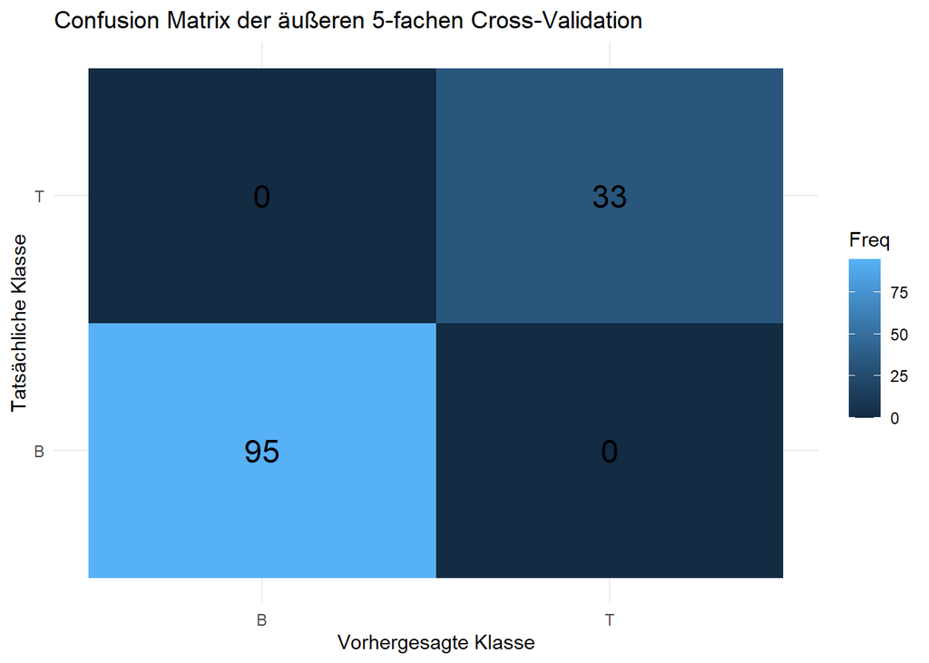

```r
# ------------------------------------------------------------
# 2. Confusion Matrix visualisieren
# ------------------------------------------------------------

if (!requireNamespace("ggplot2", quietly = TRUE)) {
  install.packages("ggplot2", repos = "https://cloud.r-project.org")
}

library(ggplot2)

ggplot(
  cm_df,
  aes(
    x = Vorhergesagt,
    y = Tatsächlich,
    fill = Freq
  )
) +
  geom_tile() +
  geom_text(
    aes(label = Freq),
    size = 6
  ) +
  labs(
    title = "Confusion Matrix der äußeren 5-fachen Cross-Validation",
    x = "Vorhergesagte Klasse",
    y = "Tatsächliche Klasse"
  ) +
  theme_minimal()
```

```r
# ------------------------------------------------------------
# 3. ROC-Kurve der äußeren Cross-Validation
# ------------------------------------------------------------

library(pROC)

target_num <- ifelse(target == "T", 1, 0)

roc_cv <- roc(
  response = target_num,
  predictor = cv_probabilities
)
auc_cv <- auc(roc_cv)

auc_cv
```

```
Area under the curve: 1
```

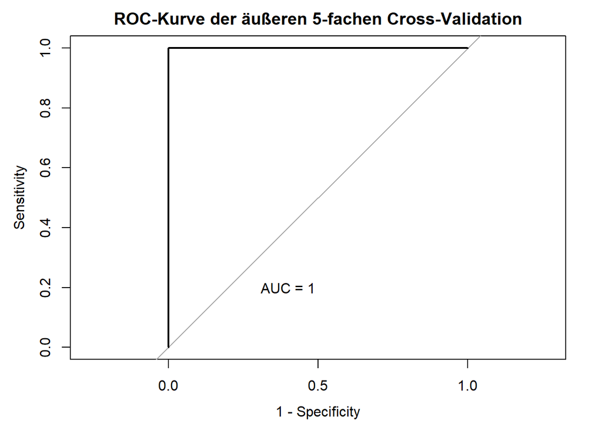

```r
# ------------------------------------------------------------
# 4. ROC-Kurve visualisieren
# ------------------------------------------------------------

plot(
  roc_cv,
  main = "ROC-Kurve der äußeren 5-fachen Cross-Validation",
  legacy.axes = TRUE
)

# AUC in die Grafik schreiben
text(
  x = 0.6,
  y = 0.2,
  labels = paste("AUC =", round(as.numeric(auc_cv), 3))
)
```

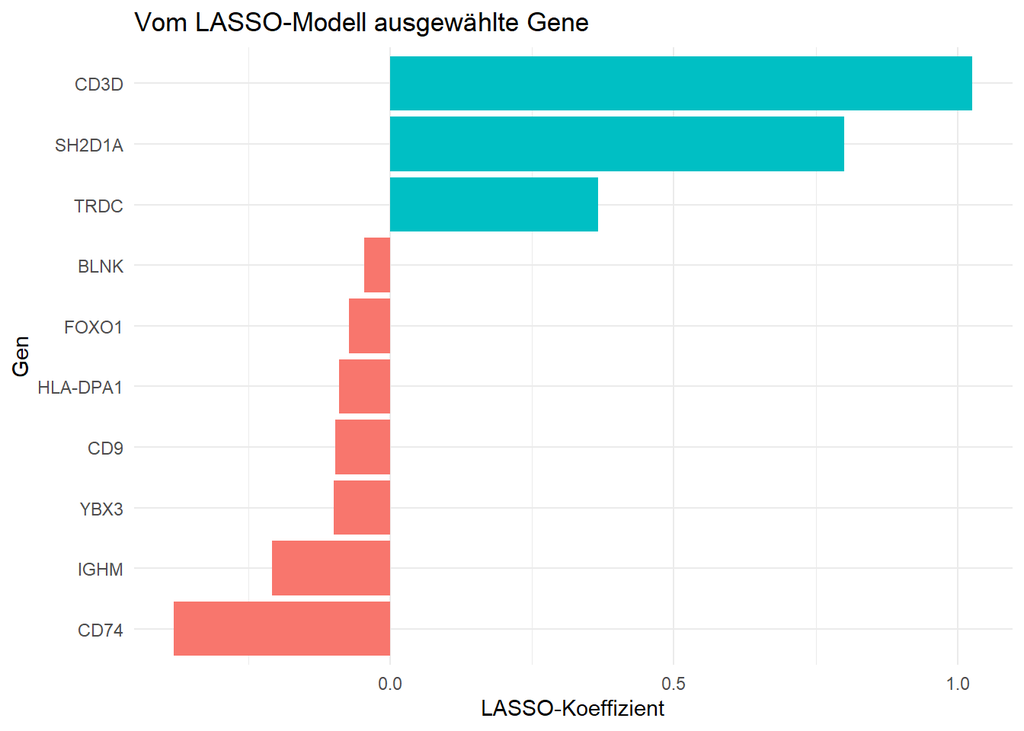

```r
# ------------------------------------------------------------
# 5. Ausgewählte LASSO-Gene visualisieren
# ------------------------------------------------------------

# Reihenfolge nach Koeffizient
selected_genes_annotated$SYMBOL <- factor(
  selected_genes_annotated$SYMBOL,
  levels = selected_genes_annotated$SYMBOL[
    order(selected_genes_annotated$Koeffizient)
  ]
)

ggplot(
  selected_genes_annotated,
  aes(
    x = SYMBOL,
    y = Koeffizient,
    fill = Koeffizient > 0
  )
) +
  geom_col() +
  coord_flip() +
  labs(
    title = "Vom LASSO-Modell ausgewählte Gene",
    x = "Gen",
    y = "LASSO-Koeffizient"
  ) +
  theme_minimal() +
  guides(fill = "none")
```

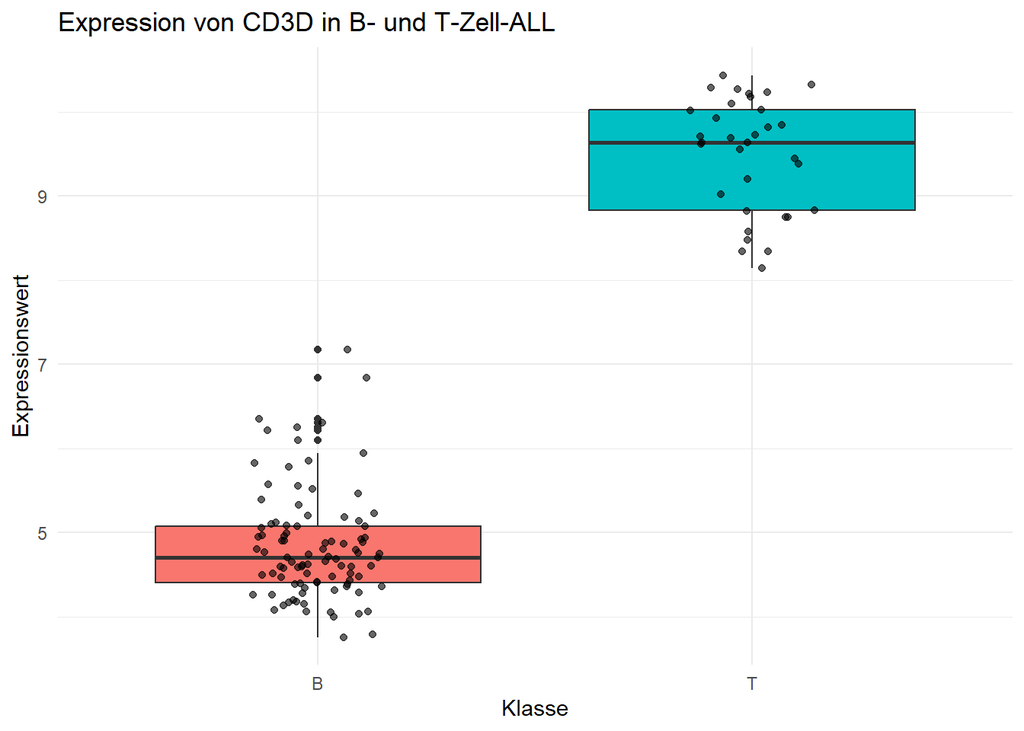

```r
# ------------------------------------------------------------
# 6. Expression ausgewählter Gene nach B/T-Gruppe
# ------------------------------------------------------------

# Probe-ID von CD3D
cd3d_probe <- "38319_at"

# Expressionswerte aus dem ALL-Datensatz
cd3d_expr <- exprs(ALL)[cd3d_probe, ]

# Data Frame für ggplot
cd3d_df <- data.frame(
  Expression = as.numeric(cd3d_expr),
  Klasse = target
)

# Boxplot
ggplot(
  cd3d_df,
  aes(
    x = Klasse,
    y = Expression,
    fill = Klasse
  )
) +
  geom_boxplot() +
  geom_jitter(
    width = 0.15,
    alpha = 0.6
  ) +
  labs(
    title = "Expression von CD3D in B- und T-Zell-ALL",
    x = "Klasse",
    y = "Expressionswert"
  ) +
  theme_minimal() +
  guides(fill = "none")
```

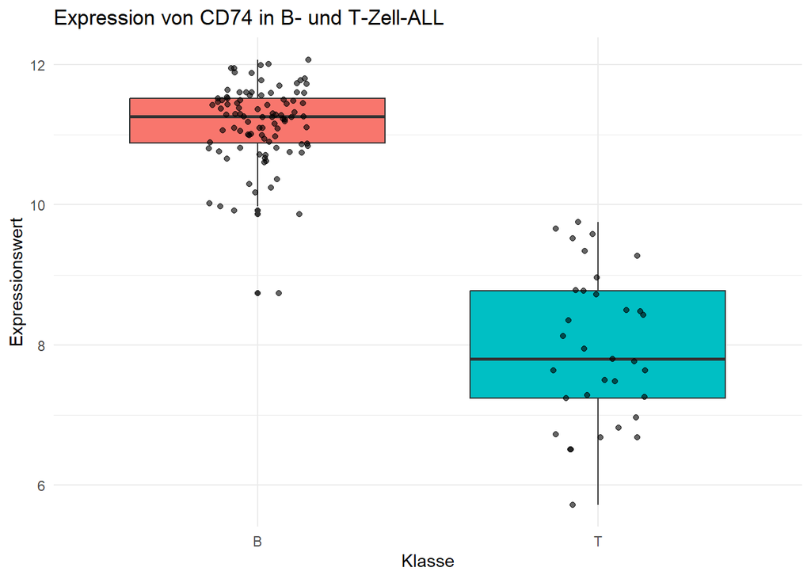

```r
# ------------------------------------------------------------
# 7. Expression von CD74
# ------------------------------------------------------------

cd74_probe <- "35016_at"

cd74_expr <- exprs(ALL)[cd74_probe, ]

cd74_df <- data.frame(
  Expression = as.numeric(cd74_expr),
  Klasse = target
)

ggplot(
  cd74_df,
  aes(
    x = Klasse,
    y = Expression,
    fill = Klasse
  )
) +
  geom_boxplot() +
  geom_jitter(
    width = 0.15,
    alpha = 0.6
  ) +
  labs(
    title = "Expression von CD74 in B- und T-Zell-ALL",
    x = "Klasse",
    y = "Expressionswert"
  ) +
  theme_minimal() +
  guides(fill = "none")
```

```r
if (!requireNamespace("pheatmap", quietly = TRUE)) {
  install.packages("pheatmap", repos = "https://cloud.r-project.org")
}

library(pheatmap)
# ------------------------------------------------------------
# 8. Heatmap der ausgewählten LASSO-Gene
# ------------------------------------------------------------

# Probe-IDs der 10 vom LASSO ausgewählten Gene
selected_probes <- selected_genes_annotated$ProbeSet

# Expressionswerte dieser Gene
heatmap_matrix <- exprs(ALL)[selected_probes, ]

# Gen-Symbole statt Probe-IDs als Zeilennamen
rownames(heatmap_matrix) <- selected_genes_annotated$SYMBOL

# Dimension kontrollieren
dim(heatmap_matrix)
```

```
[1]  10 128
```

```r
# Klassenzugehörigkeit der Proben für die Heatmap
annotation_col <- data.frame(
  Klasse = target
)

# Probennamen müssen mit den Spalten der Expressionsmatrix übereinstimmen
rownames(annotation_col) <- colnames(heatmap_matrix)

# Kontrolle
dim(annotation_col)
```

```
[1] 128   1
```

```r
table(annotation_col$Klasse)
```

```
 B  T
95 33
```

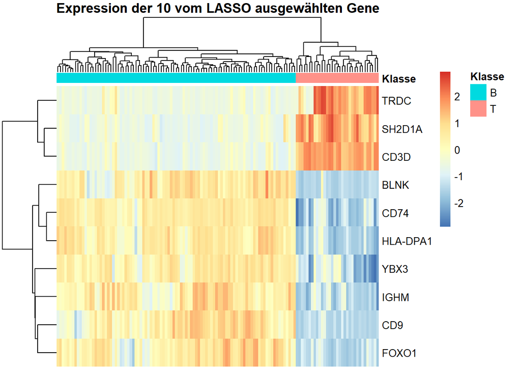

```r
# ------------------------------------------------------------
# 9. Heatmap der 10 LASSO-Gene
# ------------------------------------------------------------

pheatmap(
  heatmap_matrix,
  scale = "row",
  annotation_col = annotation_col,
  show_colnames = FALSE,
  cluster_rows = TRUE,
  cluster_cols = TRUE,
  main = "Expression der 10 vom LASSO ausgewählten Gene"
)
```

```r
# ------------------------------------------------------------
# Zusammenfassung der Visualisierung
# ------------------------------------------------------------

# Die Visualisierungen zeigen eine klare Trennung zwischen
# B-Zell-ALL und T-Zell-ALL.
#
# Die Confusion Matrix der äußeren 5-fachen Cross-Validation
# zeigt keine Fehlklassifikationen (Accuracy = 1).
# Die ROC-Analyse bestätigt die hohe Trennleistung mit AUC = 1.
#
# Das LASSO-Modell wählte 10 Gene aus.
# CD3D, SH2D1A und TRDC besitzen positive Koeffizienten und sind
# mit der T-Zell-Klasse assoziiert, während unter anderem CD74,
# IGHM und BLNK negative Koeffizienten besitzen.
#
# Die Boxplots von CD3D und CD74 zeigen deutliche Unterschiede
# zwischen den beiden Klassen.
#
# Auch die Heatmap der 10 ausgewählten Gene zeigt unterschiedliche
# Expressionsmuster und eine klare Gruppierung der B- und T-Zell-ALL-Proben.
#
# Insgesamt stimmen die Ergebnisse der Visualisierung mit den
# Ergebnissen des LASSO-Klassifikationsmodells überein.
```

## Confusion Matrix

Die Confusion Matrix der äußeren 5-fachen Cross-Validation zeigt, dass alle 128 Proben korrekt klassifiziert wurden.

Alle 95 B-Zell-ALL-Proben wurden als B-Zell-ALL und alle 33 T-Zell-ALL-Proben als T-Zell-ALL vorhergesagt. Es traten keine falsch positiven oder falsch negativen Klassifikationen auf.

Diese Darstellung bestätigt die sehr hohe Trennleistung des LASSO-Modells innerhalb des untersuchten Datensatzes.

## ROC-Kurve

Die ROC-Kurve wurde auf Grundlage der vorhergesagten Klassifikationswahrscheinlichkeiten aus der äußeren Cross-Validation erstellt.

Mit einer AUC von 1,00 zeigt sich eine vollständige Trennung zwischen B-Zell-ALL und T-Zell-ALL.

Die ROC-Analyse bestätigt damit die Ergebnisse der Confusion Matrix.

## LASSO-Koeffizienten

Die Darstellung der LASSO-Koeffizienten zeigt, welche Gene vom Modell für die Klassifikation ausgewählt wurden und in welche Richtung sie die Vorhersage beeinflussen.

Da T-Zell-ALL als Klasse 1 definiert wurde, verschieben positive Koeffizienten die Modellvorhersage in Richtung T-Zell-ALL. Negative Koeffizienten verschieben sie in Richtung B-Zell-ALL.

Zu den Genen mit positiven Koeffizienten gehören unter anderem `CD3D`, `TRDC` und `SH2D1A`.

Zu den Genen mit negativen Koeffizienten gehören unter anderem `CD74`, `IGHM`, `BLNK`, `CD9`, `YBX3`, `FOXO1` und `HLA-DPA1`.

## Expression von CD3D

Der Boxplot für `CD3D` zeigt einen deutlichen Unterschied zwischen B-Zell-ALL und T-Zell-ALL.

Die Expression von `CD3D` ist in den T-Zell-ALL-Proben deutlich höher als in den B-Zell-ALL-Proben.

Dieses Expressionsmuster stimmt mit dem positiven LASSO-Koeffizienten von `CD3D` überein und erklärt, warum dieses Gen zur Klassifikation in Richtung T-Zell-ALL beiträgt.

## Expression von CD74

Auch für `CD74` zeigt sich ein deutlicher Expressionsunterschied zwischen den beiden Klassen.

Die Expression von `CD74` ist in den B-Zell-ALL-Proben höher als in den T-Zell-ALL-Proben.

Dies stimmt mit dem negativen LASSO-Koeffizienten von `CD74` überein und unterstützt seine Bedeutung für die Klassifikation in Richtung B-Zell-ALL.

## Heatmap der ausgewählten Gene

Die Heatmap der 10 vom LASSO-Modell ausgewählten Gene zeigt deutlich unterschiedliche Expressionsmuster zwischen den B-Zell-ALL- und T-Zell-ALL-Proben.

Die hierarchische Gruppierung der Proben führt zu zwei deutlich unterschiedlichen Bereichen, die weitgehend mit den beiden biologischen Klassen übereinstimmen.

Gene wie `CD3D`, `TRDC` und `SH2D1A` zeigen insbesondere bei T-Zell-ALL eine erhöhte relative Expression.

Andere Gene wie `CD74`, `IGHM` und `BLNK` zeigen dagegen stärkere Expressionssignale in den B-Zell-ALL-Proben.

Die Heatmap verdeutlicht damit, dass nicht nur einzelne Gene, sondern ein kombiniertes Expressionsmuster der ausgewählten Gene zur Trennung der beiden Klassen beiträgt.

## Zwischenfazit

Die unterschiedlichen Visualisierungen liefern konsistente Ergebnisse.

Die Confusion Matrix und die ROC-Kurve zeigen eine sehr hohe Modellleistung, während die LASSO-Koeffizienten, Boxplots und die Heatmap die zugrunde liegenden Unterschiede in den Genexpressionsmustern sichtbar machen.

Damit unterstützen die Visualisierungen sowohl die statistische Bewertung des Klassifikationsmodells als auch die Interpretation der vom LASSO-Modell ausgewählten Gene.

# Diskussion

Die Ergebnisse zeigen, dass Genexpressionsdaten eine deutliche molekulare Struktur aufweisen und zur Unterscheidung verschiedener Leukämiegruppen genutzt werden können.

Die explorative Analyse des `ALLMLL`-Datensatzes zeigte, dass nach der Qualitätskontrolle und RMA-Normalisierung keine stark auffälligen Arrays identifiziert werden mussten. PCA und Clustering lieferten Hinweise auf eine Strukturierung der Proben anhand ihrer Expressionsprofile.

Für die überwachte Klassifikation wurde der `ALL`-Datensatz verwendet, da dieser geeignete phänotypische Informationen zur Unterscheidung zwischen B-Zell-ALL und T-Zell-ALL enthält.

Das LASSO-Modell erreichte sowohl bei der Train-/Test-Evaluation als auch bei der äußeren 5-fachen Cross-Validation eine sehr hohe Klassifikationsleistung. In der äußeren Cross-Validation wurden alle 128 Proben korrekt klassifiziert und eine AUC von 1,00 erreicht.

Die ausgewählten Gene liefern eine mögliche biologische Erklärung für diese deutliche Trennung. Beispielsweise zeigte `CD3D` eine deutlich höhere Expression in den T-Zell-ALL-Proben und besaß einen positiven LASSO-Koeffizienten. `CD74` zeigte dagegen eine höhere Expression in den B-Zell-ALL-Proben und einen negativen Koeffizienten.

Auch die Heatmap der 10 vom LASSO-Modell ausgewählten Gene zeigte unterschiedliche Expressionsmuster zwischen den beiden Klassen. Damit stimmen die Ergebnisse der Modellierung und der Expressionsvisualisierung miteinander überein.

## Limitationen

Trotz der sehr hohen Klassifikationsleistung müssen die Ergebnisse vorsichtig interpretiert werden.

Eine wesentliche Einschränkung ist die begrenzte Anzahl an Proben. Insbesondere die T-Zell-ALL-Gruppe ist mit 33 Proben deutlich kleiner als die B-Zell-ALL-Gruppe mit 95 Proben.

Darüber hinaus wurde die Modellleistung zwar mittels einer äußeren 5-fachen Cross-Validation untersucht, jedoch nicht anhand eines vollständig unabhängigen externen Datensatzes validiert. Eine Accuracy und AUC von jeweils 1,00 zeigen daher eine perfekte Trennung innerhalb des untersuchten Datensatzes, garantieren jedoch nicht, dass dieselbe Leistung bei neuen Patientenkohorten erreicht wird.

Eine weitere Einschränkung besteht darin, dass für unterschiedliche Analyseschritte zwei Datensätze verwendet wurden. `ALLMLL` wurde für Qualitätskontrolle, Normalisierung und explorative Analysen verwendet, während die B-/T-Zell-Klassifikation mit dem `ALL`-Datensatz durchgeführt wurde. Die Ergebnisse dieser beiden Analysenteile sollten daher nicht als direkte Analyse derselben Proben interpretiert werden.

Außerdem zeigen die vom LASSO-Modell ausgewählten Gene statistische Zusammenhänge mit der Klassifikation. Aus den Koeffizienten kann jedoch keine kausale Rolle der Gene bei der Entstehung der Erkrankung abgeleitet werden.

Für weiterführende Untersuchungen wäre insbesondere eine Validierung des Klassifikationsmodells mit einer unabhängigen Kohorte sinnvoll. Zusätzlich könnten alternative Klassifikationsverfahren mit dem LASSO-Modell verglichen werden.

# Fazit

Im Rahmen dieser Projektarbeit wurden verschiedene Methoden der Datenanalyse auf Microarray-Genexpressionsdaten akuter lymphoblastischer Leukämien angewendet. Die Analyse umfasste Qualitätskontrolle, Normalisierung, explorative Datenanalyse, Clustering sowie eine überwachte Klassifikation mittels Machine Learning.

Die Qualitätskontrolle des `ALLMLL`-Datensatzes ergab keine stark auffälligen Arrays. Nach der RMA-Normalisierung standen vergleichbare Expressionsdaten für die explorative Analyse zur Verfügung. PCA und Clustering zeigten, dass die Genexpressionsdaten eine erkennbare interne Struktur besitzen.

Für die Klassifikation von B-Zell-ALL und T-Zell-ALL wurde auf Grundlage des `ALL`-Datensatzes eine LASSO-logistische Regression entwickelt. In der äußeren 5-fachen Cross-Validation wurden alle 128 untersuchten Proben korrekt klassifiziert. Die Accuracy betrug 1,00 und die ROC-Analyse ergab eine AUC von 1,00.

Das LASSO-Modell selektierte 10 Probe-Sets, die anschließend Gensymbolen zugeordnet wurden und zur Unterscheidung der beiden Klassen beitrugen. Die Expressionsmuster ausgewählter Gene wie `CD3D` und `CD74` sowie die Heatmap der ausgewählten Gene unterstützten die beobachtete Trennung zwischen B-Zell-ALL und T-Zell-ALL.

Insgesamt zeigen die Ergebnisse, dass Genexpressionsdaten in dem untersuchten Datensatz eine sehr deutliche Unterscheidung zwischen B-Zell-ALL und T-Zell-ALL ermöglichen. Die Ergebnisse unterstützen damit die aufgestellte Hypothese, dass die beiden Gruppen unterschiedliche Genexpressionsprofile aufweisen, die für eine Klassifikation genutzt werden können.

Aufgrund der begrenzten Stichprobengröße und der fehlenden externen Validierung sollte die perfekte Klassifikationsleistung jedoch nicht als allgemeingültige Vorhersageleistung interpretiert werden. Eine Validierung an einer unabhängigen Patientenkohorte wäre ein sinnvoller nächster Schritt.

## Verwendung KI-gestützter Werkzeuge

Im Rahmen dieser Projektarbeit wurde ChatGPT unterstützend eingesetzt. Die Nutzung umfasste insbesondere die Erklärung einzelner Methoden und R-Funktionen, die Klärung von Unklarheiten und nicht vollständig verstandenen Inhalten, die Unterstützung bei der Erstellung und Fehlersuche von R-Code sowie bei der Behebung von Render-, Paketinstallations- und Quarto-Ausgabeproblemen, einschließlich der Anpassung der HTML-Ausgabe zur Vermeidung technischer Probleme beim Committen in Git. Darüber hinaus wurde ChatGPT zur sprachlichen Überarbeitung einzelner Textpassagen verwendet. Die verwendeten Vorschläge wurden von den Gruppenmitgliedern geprüft, nachvollzogen und gegebenenfalls angepasst.